# Homework 05

Set a random seed before each simulation question and report it. You may use standard packages unless a question asks you to write the calculation yourself. Use equal neighbor weights throughout. Here $p$ counts the covariates used to measure distance; do not add an intercept column to a KNN predictor matrix. R and Python use different random-number generators, so their exact simulation results need not agree.

## Question 1: Estimate the bias and variance of KNN

In our previous homework, we used repeated simulations to study the behavior of linear regression estimators. We will now use the same idea for KNN. Consider the regression model

$$Y_i=f(\mathbf X_i)+\epsilon_i,
\qquad
f(\mathbf x)=0.5x_1+\sin(x_2)-0.3x_3^2,$$

where the three covariates are independent standard normal variables and $\epsilon_i\sim\mathcal N(0,0.1^2)$ independently of the covariates and other observations. Generate $n=400$ training observations. Our goal is to estimate the mean response at

$$\mathbf x_0=(0.5,0.7,1)^{\mathsf T}.$$

Use Euclidean distance and consider $k=1,3,5,\ldots,29$.

1. Calculate $f(\mathbf x_0)$. Generate one training dataset and obtain the KNN prediction at $\mathbf x_0$ for each value of $k$.

• Solution:

The true mean response at $\mathbf{x}_0=(0.5,0.7,1)^{\mathsf T}$ is

$$f(\mathbf{x}_0)
=0.5(0.5)+\sin(0.7)-0.3(1)^2
=0.5942.$$

**Show the workflow**

```r
set.seed(4321)
cat("Seed used: 4321\n")
```

```
Seed used: 4321
```

**Show the workflow**

```r
n = 400
k.values = seq(1, 29, by = 2)
x0 = c(0.5, 0.7, 1)

X = matrix(rnorm(n * 3), nrow = n, ncol = 3)

f = 0.5 * X[, 1] + sin(X[, 2]) - 0.3 * X[, 3]^2
y = f + rnorm(n, mean = 0, sd = 0.1)

f0 = 0.5 * x0[1] + sin(x0[2]) - 0.3 * x0[3]^2

distances = sqrt(rowSums((X - matrix(x0, n, 3, byrow = TRUE))^2))
neighbor.order = order(distances)

predictions = sapply(k.values, function(k) {
  mean(y[neighbor.order[1:k]])
})

data.frame(
  k = k.values,
  prediction = round(predictions, 4)
)
```

```
    k prediction
1   1     0.2198
2   3     0.2841
3   5     0.4061
4   7     0.4840
5   9     0.4298
6  11     0.3914
7  13     0.4155
8  15     0.4810
9  17     0.4929
10 19     0.4282
11 21     0.4157
12 23     0.4736
13 25     0.4368
14 27     0.4239
15 29     0.3664
```

2. Independently repeat the generation of the training covariates and responses 200 times. Within each repetition, use the same training data for every value of $k$. Store the predictions in a matrix with 200 rows and one column for each value of $k$. Use this matrix to estimate the bias, variance, and mean squared error of the estimated mean response. Use divisor 200 when calculating the empirical variance, and verify numerically that

$$\text{mean squared error}
=\text{squared bias}+\text{variance}.$$

Plot squared bias, variance, and mean squared error against $k$ in one figure. Explain the pattern and compare it with the bias-variance trade-off for ridge regression or lasso.

• Solution:

**Show the workflow**

```r
set.seed(4322)
cat("Seed used: 4322\n")
```

```
Seed used: 4322
```

**Show the workflow**

```r
n = 400
B = 200
k.values = seq(1, 29, by = 2)
x0 = c(0.5, 0.7, 1)

f0 = 0.5 * x0[1] + sin(x0[2]) - 0.3 * x0[3]^2

pred.matrix = matrix(
  NA,
  nrow = B,
  ncol = length(k.values)
)

for (b in 1:B) {

  X = matrix(rnorm(n * 3), nrow = n, ncol = 3)

  f = 0.5 * X[, 1] + sin(X[, 2]) - 0.3 * X[, 3]^2
  y = f + rnorm(n, mean = 0, sd = 0.1)

  distances = sqrt(rowSums((X - matrix(x0, n, 3, byrow = TRUE))^2))
  neighbor.order = order(distances)

  for (j in seq_along(k.values)) {
    k = k.values[j]
    pred.matrix[b, j] = mean(y[neighbor.order[1:k]])
  }
}

mean.pred = colMeans(pred.matrix)

bias = mean.pred - f0
bias.squared = bias^2

variance = colMeans(
  (pred.matrix - matrix(mean.pred, B, length(k.values), byrow = TRUE))^2
)

mse = colMeans((pred.matrix - f0)^2)

results = data.frame(
  k = k.values,
  squared.bias = bias.squared,
  variance = variance,
  mse = mse,
  bias2.plus.variance = bias.squared + variance
)

round(results, 6)
```

```
    k squared.bias variance      mse bias2.plus.variance
1   1     0.000366 0.036372 0.036738            0.036738
2   3     0.000526 0.019807 0.020333            0.020333
3   5     0.001005 0.013035 0.014040            0.014040
4   7     0.001691 0.009552 0.011244            0.011244
5   9     0.002806 0.008814 0.011619            0.011619
6  11     0.004268 0.008317 0.012584            0.012584
7  13     0.005471 0.007370 0.012841            0.012841
8  15     0.006373 0.006835 0.013209            0.013209
9  17     0.007203 0.006837 0.014039            0.014039
10 19     0.008715 0.006595 0.015309            0.015309
11 21     0.009009 0.006357 0.015366            0.015366
12 23     0.010201 0.006230 0.016431            0.016431
13 25     0.011045 0.005627 0.016673            0.016673
14 27     0.012156 0.005423 0.017580            0.017580
15 29     0.013909 0.005798 0.019707            0.019707
```

**Show the workflow**

```r
max(abs(mse - (bias.squared + variance)))
```

```
[1] 5.20417e-17
```

**Show the workflow**

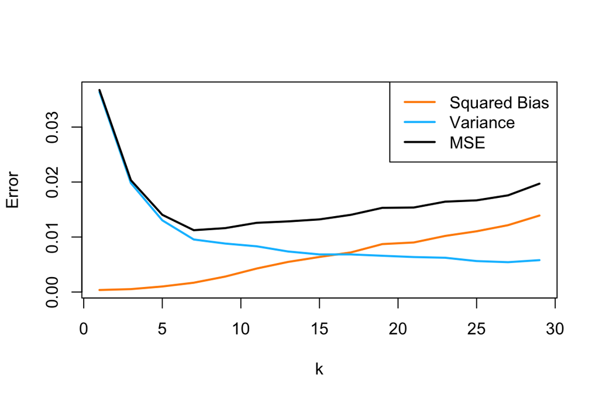

```r
plot(
  k.values, bias.squared,
  type = "l", lwd = 2,
  col = "darkorange",
  xlab = "k",
  ylab = "Error",
  ylim = range(c(bias.squared, variance, mse))
)

lines(k.values, variance,
      lwd = 2, col = "deepskyblue")

lines(k.values, mse,
      lwd = 2, col = "black")

legend(
  "topright",
  legend = c("Squared Bias", "Variance", "MSE"),
  col = c("darkorange", "deepskyblue", "black"),
  lty = 1,
  lwd = 2
)
```

The numerical difference between MSE and squared bias plus variance is essentially zero, which verifies

$$\text{MSE}=\text{Bias}^2+\text{Variance}.$$

As $k$ increases, each KNN prediction averages more observations. This generally lowers the variance because the prediction becomes less sensitive to individual training observations. At the same time, using more neighbors means averaging observations farther away from $\mathbf{x}_0$, so the squared bias tends to increase. The MSE balances these two effects and is usually lowest at an intermediate value of $k$.

This is similar to ridge regression and lasso. A small $k$ gives a more flexible KNN fit with lower bias but higher variance. Increasing $k$ adds more smoothing, giving higher bias but lower variance. This is similar to increasing the penalty $\lambda$ in ridge or lasso, which increases shrinkage and generally trades lower variance for higher bias.

## Question 2: Compare KNN with lasso

Use the response model from Question 1, including the noise standard deviation $0.1$, but generate $p=30$ covariates. The response still depends only on the first three. Consider these two settings:

- **Setting 1:** all 30 covariates are independent standard normal variables.
- **Setting 2:** the covariates have a multivariate normal distribution with mean zero and covariance matrix $\boldsymbol\Sigma$, where

  $$\Sigma_{jj}=1,
  \qquad
  \Sigma_{jl}=0.8\quad\text{for }j\ne l.$$

In each setting, generate 400 training observations and 1,000 independent test observations. Fit 5NN using Euclidean distance on the supplied covariate scale. All covariates already have population variance one.

For lasso, use a linear model containing the 30 covariates and a separately fitted, unpenalized intercept. Follow the Week 4 objective,

$$L_\lambda(\boldsymbol\beta)
=\frac{1}{2n}\left\lVert
\widetilde{\mathbf y}-\mathbf X\boldsymbol\beta
\right\rVert_2^2
+\lambda\lVert\boldsymbol\beta\rVert_1,$$

where $\mathbf X\in\mathbb R^{n\times30}$ contains the centered and standardized covariates and $\widetilde{\mathbf y}$ is the centered training response. Select the penalty by ten-fold cross-validation over 41 logarithmically spaced values from $10^{-4}$ to $1$. Estimate all means and scales using only the training portion of each fold, with divisor equal to that portion’s sample size. After selecting the penalty, refit on all training observations and apply the fitted transformations unchanged to the test observations. Do not add nonlinear terms to the lasso model.

1. Fit both methods in each setting. Use the same training and test data for the two methods within a setting. Report their test MSE values in one table, together with the selected lasso penalty and the number of nonzero lasso slopes. You only need to generate one dataset for each setting; repeated simulations are not required.

• Solution:

**Show the workflow**

```r
library(MASS)
library(kknn)
library(glmnet)
```

**Show the workflow**

```r
n_train = 400
n_test = 1000
p = 30
lambda_grid = 10^seq(0, -4, length.out = 41)

make_response = function(X) {
  0.5 * X[, 1] + sin(X[, 2]) - 0.3 * X[, 3]^2 +
    rnorm(nrow(X), mean = 0, sd = 0.1)
}

fit_methods = function(X, y) {

  colnames(X) = paste0("X", 1:p)

  X_train = X[1:n_train, ]
  X_test = X[(n_train + 1):(n_train + n_test), ]
  y_train = y[1:n_train]
  y_test = y[(n_train + 1):(n_train + n_test)]

  # 5NN with equal neighbor weights
  knn_train = data.frame(y = y_train, X_train)
  knn_test = data.frame(X_test)

  knn_fit = kknn(
    y ~ .,
    train = knn_train,
    test = knn_test,
    k = 5,
    kernel = "rectangular"
  )

  knn_pred = knn_fit$fitted.values
  knn_mse = mean((y_test - knn_pred)^2)

  # Ten balanced folds for lasso
  foldid = sample(rep(1:10, each = n_train / 10))

  lasso_cv = cv.glmnet(
    x = X_train,
    y = y_train,
    family = "gaussian",
    alpha = 1,
    lambda = lambda_grid,
    foldid = foldid,
    type.measure = "mse",
    standardize = TRUE,
    intercept = TRUE
  )

  selected_lambda = lasso_cv$lambda.min

  lasso_pred = as.numeric(
    predict(lasso_cv, newx = X_test, s = "lambda.min")
  )

  lasso_mse = mean((y_test - lasso_pred)^2)

  lasso_coef = as.numeric(
    coef(lasso_cv, s = "lambda.min")
  )

  nonzero_slopes = sum(lasso_coef[-1] != 0)

  c(
    knn_mse = knn_mse,
    lasso_mse = lasso_mse,
    lambda = selected_lambda,
    nonzero = nonzero_slopes
  )
}

# Setting 1: independent covariates
seed_setting1 = 43251
set.seed(seed_setting1)

X1 = matrix(
  rnorm((n_train + n_test) * p),
  nrow = n_train + n_test,
  ncol = p
)

y1 = make_response(X1)
result1 = fit_methods(X1, y1)

# Setting 2: correlated covariates
seed_setting2 = 43252
set.seed(seed_setting2)

Sigma = matrix(0.8, nrow = p, ncol = p)
diag(Sigma) = 1

X2 = MASS::mvrnorm(
  n = n_train + n_test,
  mu = rep(0, p),
  Sigma = Sigma
)

y2 = make_response(X2)
result2 = fit_methods(X2, y2)

cat("Setting 1 seed:", seed_setting1, "\n")
```

```
Setting 1 seed: 43251
```

**Show the workflow**

```r
cat("Setting 2 seed:", seed_setting2, "\n\n")
```

```
Setting 2 seed: 43252
```

**Show the workflow**

```r
results = data.frame(
  Setting = c("Setting 1", "Setting 2"),
  "5NN test MSE" = round(c(result1["knn_mse"],
                           result2["knn_mse"]), 4),
  "Lasso test MSE" = round(c(result1["lasso_mse"],
                             result2["lasso_mse"]), 4),
  "Selected lasso penalty" = round(c(result1["lambda"],
                                     result2["lambda"]), 6),
  "Nonzero lasso slopes" = c(result1["nonzero"],
                              result2["nonzero"]),
  check.names = FALSE
)

knitr::kable(results)
```

| Setting | 5NN test MSE | Lasso test MSE | Selected lasso penalty | Nonzero lasso slopes |
| --- | --- | --- | --- | --- |
| Setting 1 | 0.5508 | 0.2514 | 0.031623 | 9 |
| Setting 2 | 0.1773 | 0.2160 | 0.019953 | 7 |

2. Compare the results between the two settings. Explain how correlation can change the usefulness of Euclidean neighborhoods, and why lasso does not use all covariates in the same way as KNN.

• Solution:

The results show that 5NN works much better in the correlated setting than in the independent setting. When all 30 covariates are independent, the 27 covariates that do not directly affect the response still count equally in the Euclidean distance. This makes it harder for KNN to find observations that are actually close in the first three important covariates.

With strong correlation, many of the 30 covariates contain overlapping information instead of acting like 30 completely separate directions. This can make the Euclidean neighborhoods more useful and improve the 5NN predictions.

Lasso handles the extra covariates differently. Instead of using every covariate to measure distance, it applies a penalty to the slopes and can set many of them exactly to zero. Therefore, lasso can reduce the effect of unnecessary covariates, while KNN always uses all 30 covariates when deciding which observations are neighbors.

3. The response model contains $\sin(X_2)$ and $X_3^2$, but the lasso fit uses only linear terms. Explain how this difference affects the comparison. Would the results justify a general claim that correlation always helps KNN, or that one method is always better? Explain why.

• Solution:

The true response contains $\sin(X_2)$ and $X_3^2$, but the lasso model only includes linear terms. This means the lasso model is not able to represent the true response function exactly. It can capture the linear effect of $X_1$ and can give a linear approximation to $\sin(X_2)$, but it cannot directly capture the curved relationship from $X_3^2$.

KNN does not assume that the response is linear, so it can adapt to these nonlinear relationships when it is able to find useful nearby observations. However, KNN also has the disadvantage of using all 30 covariates in its distance calculation.

The results from these two datasets do not justify saying that correlation always helps KNN or that one method is always better. Correlation can change which observations appear close under Euclidean distance, and this can either help or hurt depending on the structure of the data. The comparison also depends on the sample size, number of covariates, value of $k$, noise level, and the form of the true response function. Since only one dataset was generated for each setting, these results describe this simulation rather than a general rule.

## Question 3: Observed dimension and latent dimension

The lecture’s handwritten digit example shows that KNN can work with many measured covariates. We will use a simulation to investigate why the structure of those covariates matters.

Let $p=100$ be the number of observed covariates and let $m$ be the number of latent variables. For each observation, generate

$$\mathbf X_i=\mathbf A\mathbf Z_i+\boldsymbol\eta_i,
\qquad
Y_i=Z_{i1}+Z_{i2}+\epsilon_i,$$

where $\mathbf A\in\mathbb R^{100\times m}$ has independent entries from Uniform$[-2,2]$. The entries of $\mathbf Z_i\in\mathbb R^m$ and $\boldsymbol\eta_i\in\mathbb R^{100}$, and the scalar $\epsilon_i$, are independent standard normal variables, also independent of $\mathbf A$. Generate $\mathbf A$ once and use it for all training and test observations in that dataset.

Compare $m=3$ and $m=30$. In each setting, generate 200 training observations and 200 independent test observations. Fit KNN using only the 100 observed covariates in $\mathbf X$, with Euclidean distance on their generated scale. The latent variables in $\mathbf Z$ are used to generate the data but are not available to the fitted model. Consider $k=2,10,18,\ldots,82$.

1. Generate one dataset for each value of $m$. Fit KNN for every value of $k$ and calculate test MSE. Within a setting, use the same training and test observations for all values of $k$.

• Solution:

**Show the workflow**

```r
library(FNN)

seed = 43253
set.seed(seed)
cat("Seed:", seed, "\n")
```

```
Seed: 43253
```

**Show the workflow**

```r
p = 100
n_train = 200
n_test = 200
k_values = seq(2, 82, by = 8)

generate_data = function(m) {

  A = matrix(runif(p * m, min = -2, max = 2),
             nrow = p, ncol = m)

  Z_train = matrix(rnorm(n_train * m),
                   nrow = n_train, ncol = m)
  Z_test = matrix(rnorm(n_test * m),
                  nrow = n_test, ncol = m)

  eta_train = matrix(rnorm(n_train * p),
                     nrow = n_train, ncol = p)
  eta_test = matrix(rnorm(n_test * p),
                    nrow = n_test, ncol = p)

  X_train = Z_train %*% t(A) + eta_train
  X_test = Z_test %*% t(A) + eta_test

  y_train = Z_train[, 1] + Z_train[, 2] + rnorm(n_train)
  y_test = Z_test[, 1] + Z_test[, 2] + rnorm(n_test)

  list(
    X_train = X_train,
    X_test = X_test,
    y_train = y_train,
    y_test = y_test
  )
}

knn_mse = function(data, k) {

  pred = FNN::knn.reg(
    train = data$X_train,
    test = data$X_test,
    y = data$y_train,
    k = k
  )$pred

  mean((data$y_test - pred)^2)
}

data_m3 = generate_data(m = 3)
data_m30 = generate_data(m = 30)

mse_m3 = sapply(k_values, function(k) knn_mse(data_m3, k))
mse_m30 = sapply(k_values, function(k) knn_mse(data_m30, k))

results = data.frame(
  k = k_values,
  `Test MSE (m = 3)` = mse_m3,
  `Test MSE (m = 30)` = mse_m30,
  check.names = FALSE
)

knitr::kable(results, digits = 4)
```

| k | Test MSE (m = 3) | Test MSE (m = 30) |
| --- | --- | --- |
| 2 | 1.6047 | 2.6088 |
| 10 | 1.1617 | 2.1184 |
| 18 | 1.1728 | 2.1552 |
| 26 | 1.1701 | 2.2191 |
| 34 | 1.2299 | 2.2389 |
| 42 | 1.2795 | 2.2193 |
| 50 | 1.3333 | 2.2300 |
| 58 | 1.4021 | 2.2499 |
| 66 | 1.4478 | 2.2846 |
| 74 | 1.4911 | 2.3177 |
| 82 | 1.5488 | 2.3460 |

2. Repeat the complete experiment 50 times, generating a new $\mathbf A$ and new observations in each repetition. Plot average test MSE against $k$, with one curve for each value of $m$. These curves compare the specified choices of $k$ in a controlled simulation; they are not a cross-validation procedure for selecting a final model.

• Solution:

**Show the workflow**

```r
library(FNN)
library(ggplot2)
```

**Show the workflow**

```r
seed = 43254
set.seed(seed)
cat("Seed:", seed, "\n")
```

```
Seed: 43254
```

**Show the workflow**

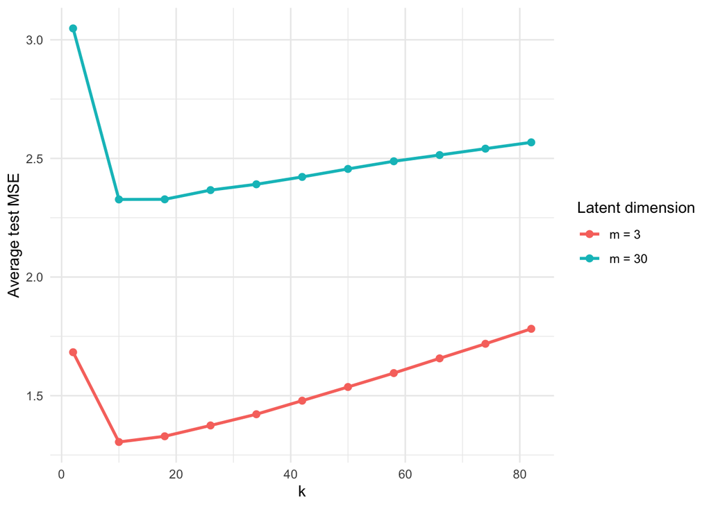

```r
p = 100
n_train = 200
n_test = 200
k_values = seq(2, 82, by = 8)
B = 50

run_one_dataset = function(m) {

  A = matrix(runif(p * m, min = -2, max = 2),
             nrow = p, ncol = m)

  Z_train = matrix(rnorm(n_train * m),
                   nrow = n_train, ncol = m)
  Z_test = matrix(rnorm(n_test * m),
                  nrow = n_test, ncol = m)

  eta_train = matrix(rnorm(n_train * p),
                     nrow = n_train, ncol = p)
  eta_test = matrix(rnorm(n_test * p),
                    nrow = n_test, ncol = p)

  X_train = Z_train %*% t(A) + eta_train
  X_test = Z_test %*% t(A) + eta_test

  y_train = Z_train[, 1] + Z_train[, 2] + rnorm(n_train)
  y_test = Z_test[, 1] + Z_test[, 2] + rnorm(n_test)

  sapply(k_values, function(k) {

    pred = FNN::knn.reg(
      train = X_train,
      test = X_test,
      y = y_train,
      k = k
    )$pred

    mean((y_test - pred)^2)
  })
}

mse_m3 = matrix(0, nrow = B, ncol = length(k_values))
mse_m30 = matrix(0, nrow = B, ncol = length(k_values))

for (b in 1:B) {
  mse_m3[b, ] = run_one_dataset(m = 3)
  mse_m30[b, ] = run_one_dataset(m = 30)
}

average_results = data.frame(
  k = rep(k_values, 2),
  Average_MSE = c(colMeans(mse_m3), colMeans(mse_m30)),
  m = factor(
    rep(c(3, 30), each = length(k_values)),
    labels = c("m = 3", "m = 30")
  )
)

ggplot(
  average_results,
  aes(x = k, y = Average_MSE, color = m)
) +
  geom_line(linewidth = 1) +
  geom_point(size = 2) +
  labs(
    x = "k",
    y = "Average test MSE",
    color = "Latent dimension"
  ) +
  theme_minimal()
```

These curves show the average test MSE over 50 independently generated datasets for each latent dimension. They compare the given values of $k$ and are not being used as a cross-validation procedure for selecting a final model.

3. Both settings have 100 observed covariates, and the response depends on only two latent variables. Explain why their KNN performance can still differ. What role does the noise $\boldsymbol\eta_i$ play, and why are the observed data not confined exactly to an $m$-dimensional linear space?

• Solution:

Even though both settings have 100 observed covariates and $Y$ depends only on $Z_1$ and $Z_2$, their KNN performance can differ because the observed covariates contain different amounts of latent information.

When $m=3$, the 100 observed covariates are mainly mixtures of only three latent variables. Two of those latent variables directly affect the response, so Euclidean distance in $\mathbf X$ is more likely to reflect differences that are useful for predicting $Y$.

When $m=30$, the observed covariates contain information from 30 latent variables, but only $Z_1$ and $Z_2$ affect the response. The other 28 latent variables still affect Euclidean distance even though they do not directly help predict $Y$. This can make it harder for KNN to find neighbors that are actually similar in the response-relevant directions.

The noise $\boldsymbol\eta_i$ also changes the geometry. Without this noise,

$$\mathbf X_i=\mathbf A\mathbf Z_i$$

would lie in the column space of $\mathbf A$, which has dimension at most $m$. However, the added noise $\boldsymbol\eta_i$ has independent components in all 100 observed directions. Therefore, each observation is pushed away from the exact latent subspace.

So the observed data have an underlying low-dimensional structure, but they are not confined exactly to an $m$-dimensional linear space. This helps explain why the latent dimension and the added noise can strongly affect how useful Euclidean neighborhoods are for KNN.